# Stat5405-Homework 4

Author

Lohit Marla

### 1.

Generally, F-Statistic is the ratio of the variance explained by the data to the variance due to random error (residuals) which indicates that the small values of F-value would reject the null hypothesis of likely the groups means are equal and specific that the groups are unequal.

The small value of 0.0004 or 0.004% which is close to 0 indicates that probability of randomly obtaining an F-statistic value that is as small as, or even smaller than, the one observed in the actual data or we would say that the differences among the group means in the analysis are highly unlikely to be due to random chance. Instead, the small F-statistic provides strong evidence that there are significant differences among the groups being compared. This is often an indicator that the factors or treatments being compared have a genuine impact on the dependent variable being studied.

### 2.a.

```r
library("ACSWR")
library("emmeans")
data("tensile")
str(tensile)
```

```
'data.frame':   25 obs. of  4 variables:
 $ Test_Sequence   : int  1 2 3 4 5 6 7 8 9 10 ...
 $ Run_Number      : int  8 18 10 23 17 5 14 6 15 20 ...
 $ CWP             : int  20 30 20 35 30 15 25 20 25 30 ...
 $ Tensile_Strength: int  12 19 17 7 25 7 14 12 18 22 ...
```

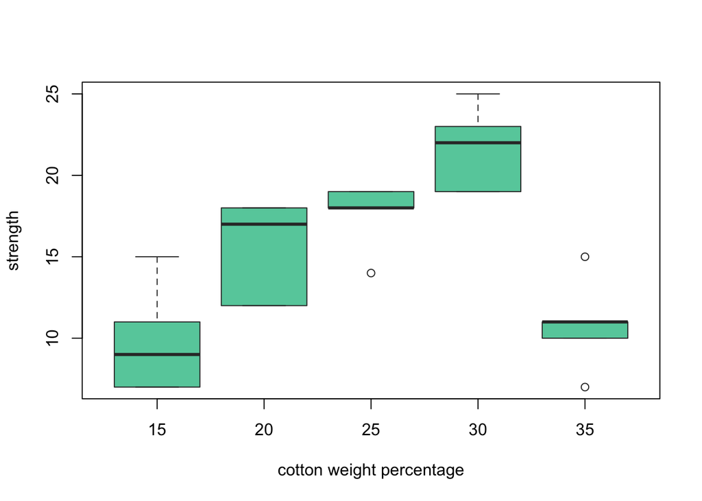

```r
boxplot(tensile$Tensile_Strength ~ tensile$CWP, xlab="cotton weight percentage",
        ylab="strength", border = "grey20", col="aquamarine3")
```

From the above chart we draw some information that the temsile strength was increased from the cwp 15% to 30% and got declined at the 35 CWP. At 15% of CWP values got extended till 15 for strength and the data looks normal whereas remaining all the other cwp from 20%-35% the data is skewed along with the outlier for 25% and 35%.

```r
#checking normality assumptions for Bartlett's Test

unique_levels <- unique(tensile$CWP)

# Perform Shapiro-Wilk test for normality for each CWP level
for(level in unique_levels) {
  subset_data <- tensile[tensile$CWP == level, ]
  shapiro_test <- shapiro.test(subset_data$Tensile_Strength)
  cat(paste("CWP Level:", level, " - p-value:", shapiro_test$p.value, "\n"))
}
```

```
CWP Level: 20  - p-value: 0.0322816051567101
CWP Level: 30  - p-value: 0.421149656082093
CWP Level: 35  - p-value: 0.679901851799461
CWP Level: 15  - p-value: 0.314039557109439
CWP Level: 25  - p-value: 0.0233242868158401
```

```r
bartlett_test_result <- bartlett.test(tensile$Tensile_Strength, tensile$CWP)
bartlett_test_result
```

```
    Bartlett test of homogeneity of variances

data:  tensile$Tensile_Strength and tensile$CWP
Bartlett's K-squared = 0.93309, df = 4, p-value = 0.9198
```

```r
tensile$CWP <- as.factor(tensile$CWP)
str(tensile)
```

```
'data.frame':   25 obs. of  4 variables:
 $ Test_Sequence   : int  1 2 3 4 5 6 7 8 9 10 ...
 $ Run_Number      : int  8 18 10 23 17 5 14 6 15 20 ...
 $ CWP             : Factor w/ 5 levels "15","20","25",..: 2 4 2 5 4 1 3 2 3 4 ...
 $ Tensile_Strength: int  12 19 17 7 25 7 14 12 18 22 ...
```

```r
aovmod <- aov(Tensile_Strength ~ factor(CWP), data = tensile)
summary(aovmod)
```

```
            Df Sum Sq Mean Sq F value   Pr(>F)
factor(CWP)  4  475.8  118.94   14.76 9.13e-06 ***
Residuals   20  161.2    8.06
---
Signif. codes:  0 '***' 0.001 '**' 0.01 '*' 0.05 '.' 0.1 ' ' 1
```

Here’s how to interpret the output:

**Df (Degrees of Freedom):** This column shows the degrees of freedom associated with the model components. In this case, there are two rows. The first row represents the factor (CWP) you’re testing, and it has 4 degrees of freedom. The second row represents the residuals (error term), and it has 20 degrees of freedom.

**Sum Sq (Sum of Squares):** This column shows the sum of squared deviations from the mean for each component. For “factor(CWP),” the sum of squares is 475.8, and for “Residuals,” it is 161.2.

**Mean Sq (Mean Sum of Squares):** This column represents the mean sum of squares, which is the sum of squares divided by the degrees of freedom. For “factor(CWP),” the mean sum of squares is 118.94 (475.8 / 4), and for “Residuals,” it is 8.06 (161.2 / 20).

**F value (F-statistic):** The F-statistic is a ratio of the variance explained by the factor (CWP) to the variance due to random error (residuals). It tests whether there are significant differences among the means of the groups defined by the factor. In the output, the F value is 14.76 for the factor (CWP).

**Pr(>F) (p-value):** This column shows the p-value associated with the F-statistic. It indicates the probability of obtaining an F-statistic as extreme as the one observed, assuming there is no significant difference among group means (the null hypothesis). In the output, the p-value is 9.13e-06, which is very close to zero and much smaller than the typical significance level (e.g., 0.05). Therefore, we would reject the null hypothesis and conclude that there are significant differences among group means.

**Signif. codes:** The significance codes indicate the level of significance. In our output, ” *** ” indicates a highly significant result (p < 0.001), emphasizing that the differences among group means are statistically significant.

### 2.b.

The $95\%$ confidence interval for $\mu_i$ is given by

$$\hat{\mu}_i \pm t_{0.975, N-a} \frac{\hat{\sigma}}{\sqrt{n_i}}
= \overline{Y}_{i\cdot} \pm t_{0.975, N-a} \frac{ \sqrt{\rm MSE} }{ \sqrt{n_i}},
\tag{1}$$

where, $\overline{Y}_{i\cdot}$ is the sample mean of responses in level $i$. The marginal 95% interval for $\mu_i$ can help us test $H_0: \mu_i = 0$.

While gives 95% coverage for each mean $\mu_i$, it does not give 95% coverage for all $a$ means considered together.

```r
pred.CWP <- expand.grid(CWP=unique(tensile$CWP))
lsmeans <- predict(aovmod, newdata=pred.CWP, se=TRUE, interval="confidence")
cbind(pred.CWP, lsmeans$fit)
```

```
  CWP  fit       lwr      upr
1  20 15.4 12.751566 18.04843
2  30 21.6 18.951566 24.24843
3  35 10.8  8.151566 13.44843
4  15  9.8  7.151566 12.44843
5  25 17.6 14.951566 20.24843
```

From the above results of all 5 groups we can observe with the lower and upper limits of each group at level $i$ which is the null hypothesis acceptance range.

### 2.c.

**Bonferroni Procedure.**

This procedure requires fewer assumptions than Tukey’s method, but is more conservative (meaning that it yields $p$-values which are greater than or equal to ones produced by Tukey’s adjustment).

To use the Bonferroni method, we use the *pairwise.t.test()* function.

```r
# All pairs, Bonferroni multiple comparison correction
pairwise.t.test(tensile$Tensile_Strength, tensile$CWP,
            p.adjust.method = "bonf")
```

```
    Pairwise comparisons using t tests with pooled SD

data:  tensile$Tensile_Strength and tensile$CWP

   15      20     25     30
20 0.0541  -      -      -
25 0.0031  1.0000 -      -
30 2.1e-05 0.0251 0.3754 -
35 1.0000  0.1859 0.0116 7.0e-05

P value adjustment method: bonferroni
```

### 2.d.

To perform all pairwise comparisons of the five means, Tukey’s Honest Significant Difference (HSD) post-hoc test is useful.

Idea: if we determine a critical value for the difference between the largest and the smallest sample means, then any other pair of sample means that differ by at least this critical value would also imply a difference in the corresponding level means.

```r
aovmod <- aov(Tensile_Strength ~ factor(CWP), data = tensile)

#pairwise comparisons Tukey's HSD test
TukeyHSD(aovmod)
```

```
  Tukey multiple comparisons of means
    95% family-wise confidence level

Fit: aov(formula = Tensile_Strength ~ factor(CWP), data = tensile)

$`factor(CWP)`
       diff         lwr        upr     p adj
20-15   5.6   0.2270417 10.9729583 0.0385024
25-15   7.8   2.4270417 13.1729583 0.0025948
30-15  11.8   6.4270417 17.1729583 0.0000190
35-15   1.0  -4.3729583  6.3729583 0.9797709
25-20   2.2  -3.1729583  7.5729583 0.7372438
30-20   6.2   0.8270417 11.5729583 0.0188936
35-20  -4.6  -9.9729583  0.7729583 0.1162970
30-25   4.0  -1.3729583  9.3729583 0.2101089
35-25  -6.8 -12.1729583 -1.4270417 0.0090646
35-30 -10.8 -16.1729583 -5.4270417 0.0000624
```

### 2.e.

Following is the procedure to calcuale the $\eta^2$ which is the effect size of the one factor anova model.

```r
anova_result <- summary(aovmod)

sum_sq_values <- anova_result[[1]]$`Sum Sq`
eta_squared_value <- sum_sq_values[1] / sum(anova_result[[1]]$`Sum Sq`)

print(eta_squared_value)
```

```
[1] 0.7469229
```

From the above result, the effect size is 0.7 by which we can confirm that there is a practical significant efffect on the data.

### 3.

```r
data("ToothGrowth")
str(ToothGrowth)
```

```
'data.frame':   60 obs. of  3 variables:
 $ len : num  4.2 11.5 7.3 5.8 6.4 10 11.2 11.2 5.2 7 ...
 $ supp: Factor w/ 2 levels "OJ","VC": 2 2 2 2 2 2 2 2 2 2 ...
 $ dose: num  0.5 0.5 0.5 0.5 0.5 0.5 0.5 0.5 0.5 0.5 ...
```

The response is len, the length of odontoblasts (cells responsible for tooth growth) in 60 guinea pigs. Each animal received one of three dose levels of vitamin C (0.5, 1, and 2 mg/day) denoted as the factor dose by one of two delivery methods, orange juice or ascorbic acid (a form of vitamin C and coded as VC), denoted as the factor supp.

```r
data("ToothGrowth")
str(ToothGrowth)
```

```
'data.frame':   60 obs. of  3 variables:
 $ len : num  4.2 11.5 7.3 5.8 6.4 10 11.2 11.2 5.2 7 ...
 $ supp: Factor w/ 2 levels "OJ","VC": 2 2 2 2 2 2 2 2 2 2 ...
 $ dose: num  0.5 0.5 0.5 0.5 0.5 0.5 0.5 0.5 0.5 0.5 ...
```

**Response variable** is going to be **len** where as the **Factor A** would be **dose** and **Factor B** would be **supp**

### 3.a.

One-factor ANOVA model relating the response len to dose (Factor A) is as follows

First, lets verify the data by plotting for the normality assumption which is one other than the variance

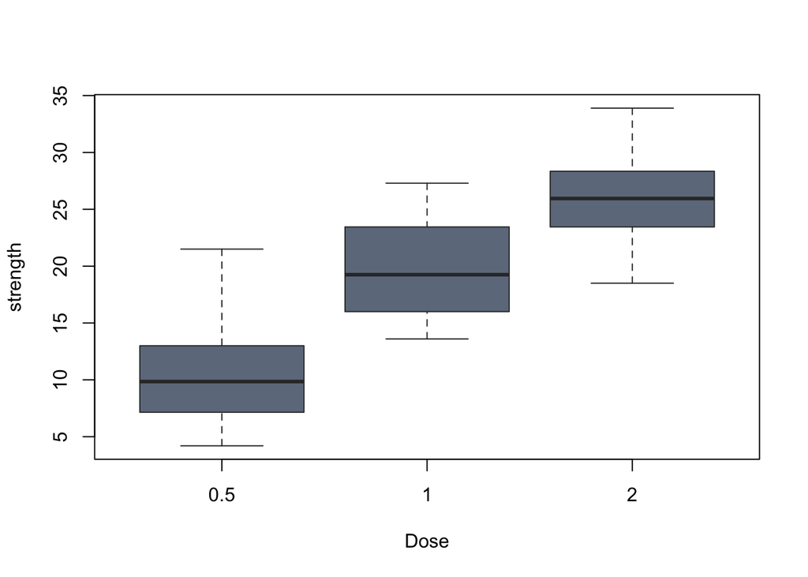

```r
boxplot(ToothGrowth$len ~ ToothGrowth$dose, xlab="Dose",
        ylab="strength", border = "grey20", col="lightsteelblue4")
```

Graphically data holds the assumption of normlaity. Let, verify statistically.

```r
#checking normality assumptions for Bartlett's Test

unique_levels <- unique(ToothGrowth$dose)

# Perform Shapiro-Wilk test for normality for each CWP level
for(level in unique_levels) {
  subset_data <- ToothGrowth[ToothGrowth$dose == level, ]
  shapiro_test <- shapiro.test(subset_data$len)
  cat(paste("Supplement Level:", level, " - p-value:", shapiro_test$p.value, "\n"))
}
```

```
Supplement Level: 0.5  - p-value: 0.246601486196049
Supplement Level: 1  - p-value: 0.163882141233336
Supplement Level: 2  - p-value: 0.901911496439863
```

Above all results we can confirm that the normality assumption was holding and we can proceed with the equal variance test called bartlett.

```r
bartlett_test_result <- bartlett.test(ToothGrowth$len, ToothGrowth$dose)
bartlett_test_result
```

```
    Bartlett test of homogeneity of variances

data:  ToothGrowth$len and ToothGrowth$dose
Bartlett's K-squared = 0.66547, df = 2, p-value = 0.717
```

P-value of the above test indicates the data holds the variance.

The mean Len are the same for each level of dose where each level is the population. The null hypothesis $H_0$ is

$$H_{0}:\mu_1=\mu_2=\mu_3
\tag{2}$$

versus the alternative hypothesis

$$H_{1}: \mbox{ not all means } \mu_{i} \mbox{ are equal}
\tag{3}$$

or

$$H_{1}: \mbox{ at least one } \mu_{i} \mbox{ is different from the others.}
\tag{4}$$

$$\mu_1 :$$
Mean len at the 0.5 dose
$$\mu_2 :$$
Mean len at the 1.0 dose
$$\mu_3 :$$
Mean len at the 2.0 dose

Equivalently, we write the null and alternative hypotheses in terms of $\tau$ effects as

$$H_{0}: \tau_1=\tau_2=\tau_3
\tag{5}$$

versus

$$H_{1}:\mbox{ not all treatment effects } \tau_{i} \mbox{ are equal},
\tag{6}$$

or

$$H_{1}: \mbox{ at least one } \tau_{i} \mbox{ is different from the others.}
\tag{7}$$

```r
aovmod <- aov(len ~ factor(dose), data = ToothGrowth)
summary(aovmod)
```

```
             Df Sum Sq Mean Sq F value   Pr(>F)
factor(dose)  2   2426    1213   67.42 9.53e-16 ***
Residuals    57   1026      18
---
Signif. codes:  0 '***' 0.001 '**' 0.01 '*' 0.05 '.' 0.1 ' ' 1
```

Smaller P-value rejects the null hypothesis of equal means of all 3 populations and conclude that atleast one population mean is different from others. However, with this test we cannot find out the pairs whose means are unequal. There are some tests related to it such as Tukeys procedure, Bonferroni Procedure.

The small p-value (9.53e-16) provides strong evidence against the null hypothesis that the dosage level (dose) has no effect on tooth length (len).

With such a small p-value, we can conclude that there is a statistically significant effect of the dosage level (dose) on tooth length (len). In other words, different dosage levels have a significant impact on tooth length in this dataset.

**Pr(>F) (p-value):** This column shows the p-value associated with the F-statistic. It indicates the probability of obtaining an F-statistic as extreme as the one observed, assuming there is no significant difference among group means (the null hypothesis). In your output, the p-value is 9.53e-16, which is very close to zero and much smaller than the typical significance level (e.g., 0.05). Therefore, you would reject the null hypothesis and conclude that there are significant differences among group means.

**Signif. codes:** The significance codes indicate the level of significance. In our output, ” *** ” indicates a highly significant result (p < 0.001), emphasizing that the differences among group means are statistically significant

```r
aovfits <- fitted(aovmod)
aovres <- residuals(aovmod)
shapiro.test(aovres)
```

```
    Shapiro-Wilk normality test

data:  aovres
W = 0.96731, p-value = 0.1076
```

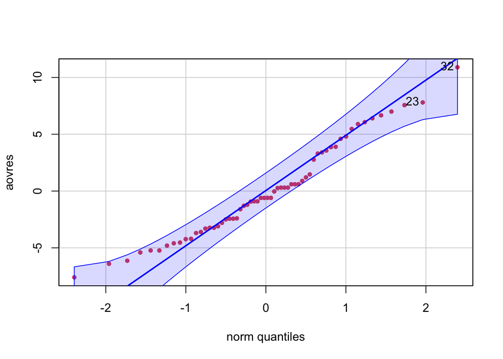

```
[1] 32 23
```

```r
car::qqPlot(aovres, main = NA, pch = 19, col = 2, cex = 0.7)
```

The large $p$-value (much greater than 0.05) from the Shapiro-Wilk significance test for normality of validates the normality assumption.

### 3.b.

First, lets verify the data by plotting for the normality assumption which is one other than the variance

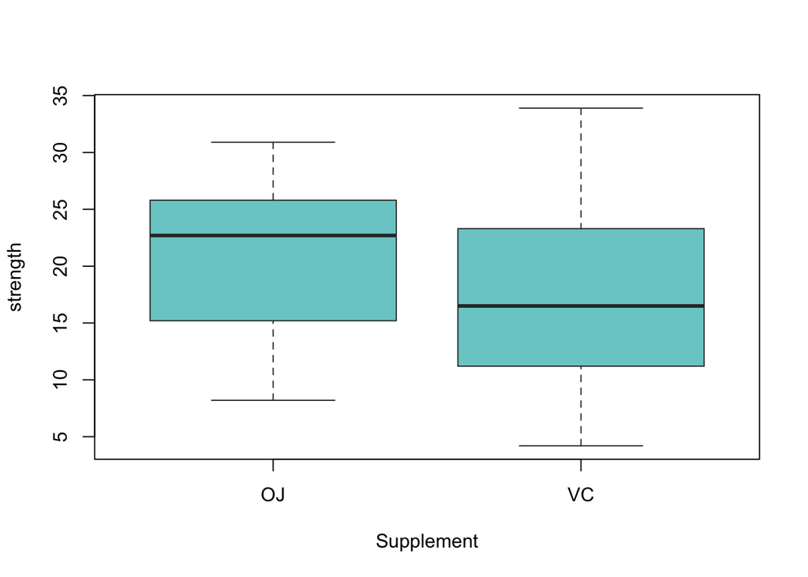

```r
boxplot(ToothGrowth$len ~ ToothGrowth$supp, xlab="Supplement",
        ylab="strength", border = "grey20", col="darkslategray3")
```

From the above box plot we can observe the data holds normality. However, lets statistically

```r
#checking normality assumptions for Bartlett's Test

unique_levels <- unique(ToothGrowth$supp)

# Perform Shapiro-Wilk test for normality for each CWP level
for(level in unique_levels) {
  subset_data <- ToothGrowth[ToothGrowth$supp == level, ]
  shapiro_test <- shapiro.test(subset_data$len)
  cat(paste("Supplement Level:", level, " - p-value:", shapiro_test$p.value, "\n"))
}
```

```
Supplement Level: VC  - p-value: 0.428446463009788
Supplement Level: OJ  - p-value: 0.0235877289994793
```

Supplement level VC’s p-value is greater than 0.05 which it proves the normality whereas the supp level OJ rejects the null hypothesis of normality as it’s p-value is less than 0.05.

Let’s log transform the data,

```r
#checking normality assumptions for Bartlett's Test

unique_levels <- unique(ToothGrowth$supp)

# Perform Shapiro-Wilk test for normality for each CWP level
for(level in unique_levels) {
  subset_data <- ToothGrowth[ToothGrowth$supp == level, ]
  shapiro_test <- shapiro.test(log10(subset_data$len))
  cat(paste("Supplement Level:", level, " - p-value:", shapiro_test$p.value, "\n"))
}
```

```
Supplement Level: VC  - p-value: 0.119816804001204
Supplement Level: OJ  - p-value: 0.000758418873753725
```

Even after the log transformation the data does not holds normality.

```r
bartlett_test_result <- bartlett.test(ToothGrowth$len, ToothGrowth$supp)
bartlett_test_result
```

```
    Bartlett test of homogeneity of variances

data:  ToothGrowth$len and ToothGrowth$supp
Bartlett's K-squared = 1.4217, df = 1, p-value = 0.2331
```

```r
bartlett_test_result <- bartlett.test(log10(ToothGrowth$len), ToothGrowth$supp)
bartlett_test_result
```

```
    Bartlett test of homogeneity of variances

data:  log10(ToothGrowth$len) and ToothGrowth$supp
Bartlett's K-squared = 4.1852, df = 1, p-value = 0.04078
```

Let’s go with the non parametric one factor anova modeling as it is less sensitivity to the variance and normality.

```r
# Kruskal-Wallis nonparametric procedure
kruskal.test(len ~ supp, data = ToothGrowth)
```

```
    Kruskal-Wallis rank sum test

data:  len by supp
Kruskal-Wallis chi-squared = 3.4454, df = 1, p-value = 0.06343
```

With the p-value greater than the significance level 0.05 we can fail to reject null hypothesis which states the equality of means of two groups supp and len

$$H_{0}:\mu_1=\mu_2
\tag{8}$$

versus the alternative hypothesis

$$H_{1}: \mbox{ not all means } \mu_{i} \mbox{ are equal}
\tag{9}$$

or

$$H_{1}: \mbox{ at least one } \mu_{i} \mbox{ is different from the others.}
\tag{10}$$

$$\mu_1 :$$
Mean len at the VC supplement
$$\mu_2 :$$
Mean len at the OJ supplement

Equivalently, we write the null and alternative hypotheses in terms of $\tau$ effects as

versus

$$H_{1}:\mbox{ not all treatment effects } \tau_{i} \mbox{ are equal},
\tag{12}$$

or

$$H_{1}: \mbox{ at least one } \tau_{i} \mbox{ is different from the others.}
\tag{13}$$

```r
aovmod <- aov(len ~ factor(supp), data = ToothGrowth)
summary(aovmod)
```

```
             Df Sum Sq Mean Sq F value Pr(>F)
factor(supp)  1    205  205.35   3.668 0.0604 .
Residuals    58   3247   55.98
---
Signif. codes:  0 '***' 0.001 '**' 0.01 '*' 0.05 '.' 0.1 ' ' 1
```

F value is 3.668, and the associated p-value for the factor supp is 0.0604. This p-value is slightly above the conventional significance level of 0.05.

Significance level of 0.05, the p-value of 0.0604 suggests that the evidence against the null hypothesis (no effect of supp on len) is not strong enough to conclude that there is a significant effect. Therefore, you might say that the results are marginally significant but do not meet the typical threshold for statistical significance

```r
aovfits <- fitted(aovmod)
aovres <- residuals(aovmod)
shapiro.test(aovres)
```

```
    Shapiro-Wilk normality test

data:  aovres
W = 0.96949, p-value = 0.1378
```

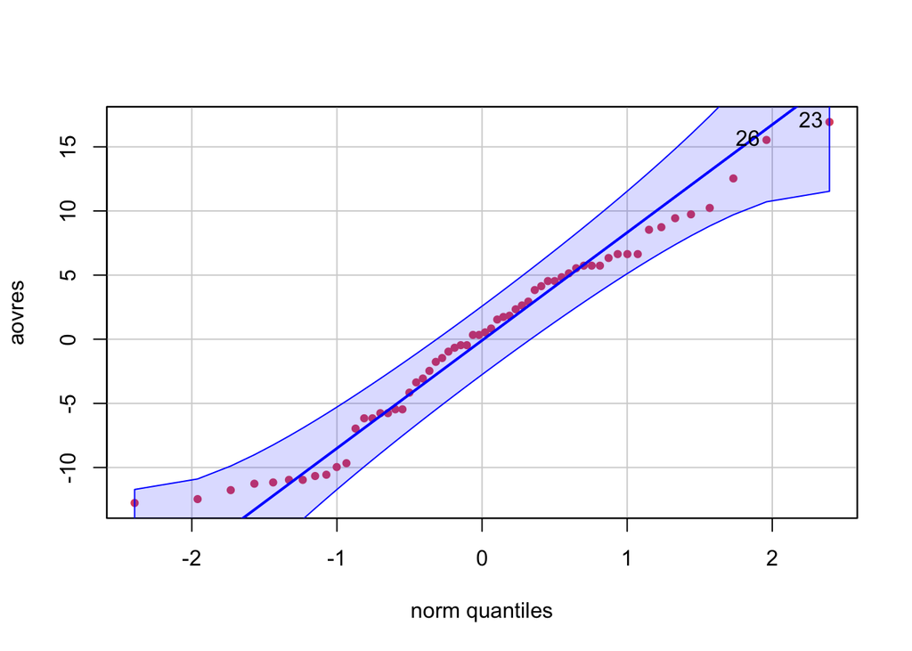

```
[1] 23 26
```

```r
car::qqPlot(aovres, main = NA, pch = 19, col = 2, cex = 0.7)
```

The large $p$-value (much greater than 0.05) from the Shapiro-Wilk significance test for normality of validates the normality assumption.

### 3.c.

```r
panelA <- aov(len ~ factor(dose)+factor(supp), data = ToothGrowth)
summary(panelA)
```

```
             Df Sum Sq Mean Sq F value   Pr(>F)
factor(dose)  2 2426.4  1213.2   82.81  < 2e-16 ***
factor(supp)  1  205.4   205.4   14.02 0.000429 ***
Residuals    56  820.4    14.7
---
Signif. codes:  0 '***' 0.001 '**' 0.01 '*' 0.05 '.' 0.1 ' ' 1
```

### 3.d.

```r
model_interaction <- lm(len ~ factor(dose) * factor(supp), data = ToothGrowth)
anova_result_interaction <- anova(model_interaction)
summary(model_interaction)
```

```
Call:
lm(formula = len ~ factor(dose) * factor(supp), data = ToothGrowth)

Residuals:
   Min     1Q Median     3Q    Max
 -8.20  -2.72  -0.27   2.65   8.27

Coefficients:
                             Estimate Std. Error t value Pr(>|t|)
(Intercept)                    13.230      1.148  11.521 3.60e-16 ***
factor(dose)1                   9.470      1.624   5.831 3.18e-07 ***
factor(dose)2                  12.830      1.624   7.900 1.43e-10 ***
factor(supp)VC                 -5.250      1.624  -3.233  0.00209 **
factor(dose)1:factor(supp)VC   -0.680      2.297  -0.296  0.76831
factor(dose)2:factor(supp)VC    5.330      2.297   2.321  0.02411 *
---
Signif. codes:  0 '***' 0.001 '**' 0.01 '*' 0.05 '.' 0.1 ' ' 1

Residual standard error: 3.631 on 54 degrees of freedom
Multiple R-squared:  0.7937,    Adjusted R-squared:  0.7746
F-statistic: 41.56 on 5 and 54 DF,  p-value: < 2.2e-16
```

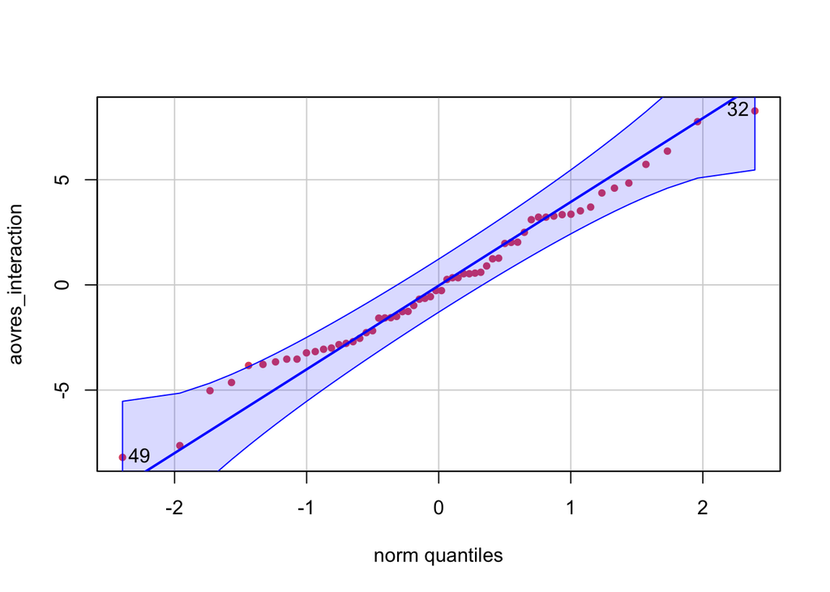

```
[1] 32 49
```

```r
library(car)
aovres_interaction <- residuals(model_interaction)
qqPlot(aovres_interaction, main = NA, pch = 19, col = 2, cex = 0.7)
```

```r
shapiro.test(aovres_interaction)
```

```
    Shapiro-Wilk normality test

data:  aovres_interaction
W = 0.98499, p-value = 0.6694
```

Residuals looks normal by the above normal q-q plot. Also, it is statisticlly proved by the shapiro test.

```r
shapiro.test(aovres_interaction)
```

```
    Shapiro-Wilk normality test

data:  aovres_interaction
W = 0.98499, p-value = 0.6694
```

### 3.e.

From 3.a We conclude that the dosage given to the patients does show impact on the length of the odontoblasts (cells responsible for tooth growth). We have statistical proof where we did one factor anova model on the data with dependent variable as length of the odntoblasts as independent variable. Data satisfied the normality and variance assumptions and so fitted the anova model and based on the p-value and f-statistic we concluded the result.

From 3.b We conclude that the supplement levels(VC and OJ) given to the patients does not impact the length of the odontoblasts (cells responsible for tooth growth). Even though the p-value is little higher than the significance value of $5%$ considering the f-statistic we can consider the effect however statistically we determine no effect on the dependent variable.

From 3.c However, after performing the two factor anova model we can conclude that both the variables Supplments as well as the doseages show considerable effect on the length of the odontoblasts.

From 3.d It indicates that length of odontoblasts was positively impacted by the dosage where as negatively by the supplements where both show considerable effect positively. Variability of the model looks good and is good fit for the model.